# Modeling and prediction for movies

## **1. Introduction and Setup**

The data set is comprised of 651 randomly sampled movies produced and released before 2016.

### 1.1 Load packages

Three packages, `ggplot2`, `dplyr` and `statsr` were loaded for the purpose of the research.

```r
library(ggplot2)
library(dplyr)
library(statsr)
```

### 1.2 Load data

The data was loaded from the file `movies.RData` in the local drive.

```r
#load("movies.Rdata")
load("D:/Dropbox/Course/Data Analytics/Duke Statistics with R/3. Regression/Week 4/movies.Rdata")
```

## **2. Research Objective**

Generally, everyone may have their unique preference in movie arts. Critics usually watches much more movies and hence may be more critical than most of the common audience. There might be some difference between the opinions of the certified critics and the audience. The research objective is described as below:

```
Could there be any linear association between the Rotten Tomatoes ratings of the critics and audience? If any, could types and genre of a movie be the predictors of this association?
```

## **3. Generalizability and Causality**

The data used in this research, Rotten Tomatoes critics rating and audience ratings, were contributed by Rotten Tomatoes users who are randomly distributed around the world. Since English is the primary language of this website, there may be more users in English speaking countries and the results may be biased **and should not be generalized to the users in countries or regions where there are few users**.

However, if Rotten Tomatoes is considered as a virtual community, the ratings may be considered as random sampled responses from the community and the results reflect the common opinions of Rotten Tomatoes users and **could be generalized to the community**. There may be voluntary response bias in the ratings, but the trends are still worth investigation.

Meanwhile, the data is completely observational since there is no random assignment designed. Therefore, there is **no causality** in this research.

## **4. Exploratory data analysis**

### 4.1 Checking Linear Regression Conditions

Before moving on to add more possible concerned variables to the model, a simple linear regression was made to show the association between the two numerical variables `critics_score` and `audience_score`. The stats of the regression is shown the the following Table 4.1.

**Table 4.1 Simple Linear Regression between `critics_score` and `audience_score`**

```r
m0 <- lm(critics_score ~ audience_score, data = movies)
summary(m0)
```

```
##
## Call:
## lm(formula = critics_score ~ audience_score, data = movies)
##
## Residuals:
##     Min      1Q  Median      3Q     Max
## -69.156 -12.395   3.017  14.508  53.551
##
## Coefficients:
##                Estimate Std. Error t value Pr(>|t|)
## (Intercept)    -3.99872    2.56579  -1.558     0.12
## audience_score  0.98917    0.03914  25.273   <2e-16 ***
## ---
## Signif. codes:  0 '***' 0.001 '**' 0.01 '*' 0.05 '.' 0.1 ' ' 1
##
## Residual standard error: 20.18 on 649 degrees of freedom
## Multiple R-squared:  0.496,  Adjusted R-squared:  0.4952
## F-statistic: 638.7 on 1 and 649 DF,  p-value: < 2.2e-16
```

The estimated slope is 0.98, very close to 1. This means that given a rating score of a movie by some audience, the critic is predicted to have similar score. The adjusted R-squared of 0.49 indicates that 49% of the variability in the percentile of critics’ score is explained by the model.

In addition to Table 4.1, the least square line is plotted together with the scatters, as shown in Figure 4.1.

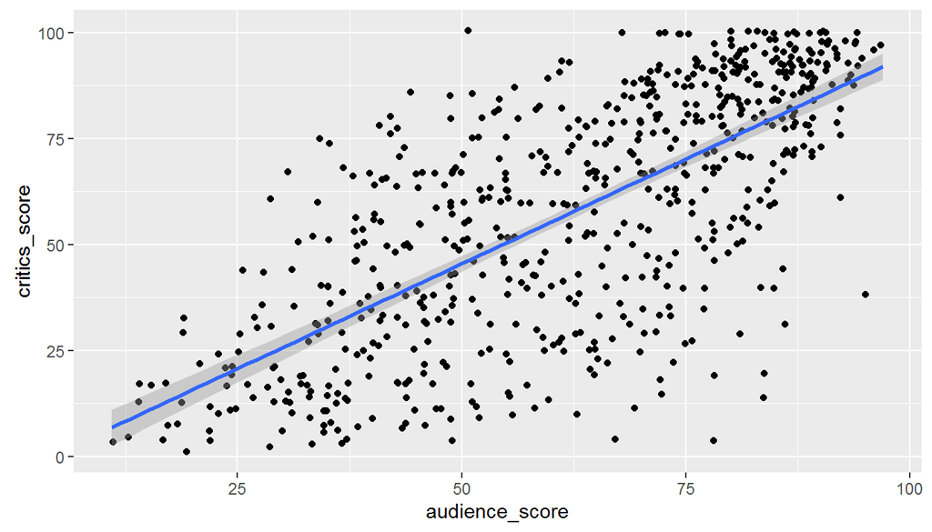

```r
ggplot(data = movies, aes(x = audience_score, y = critics_score))+
  geom_jitter() +
  geom_smooth(method = "lm")
```

**Figure 4.1 Scatter Plot and the Predicted Line**

It is seen in Figure 4.1 that there are much scatter according to the line, but generally the points show a positive corralation and a linear trend.

In Figure 4.2, the residuals of this regression are plotted against the fitted values.

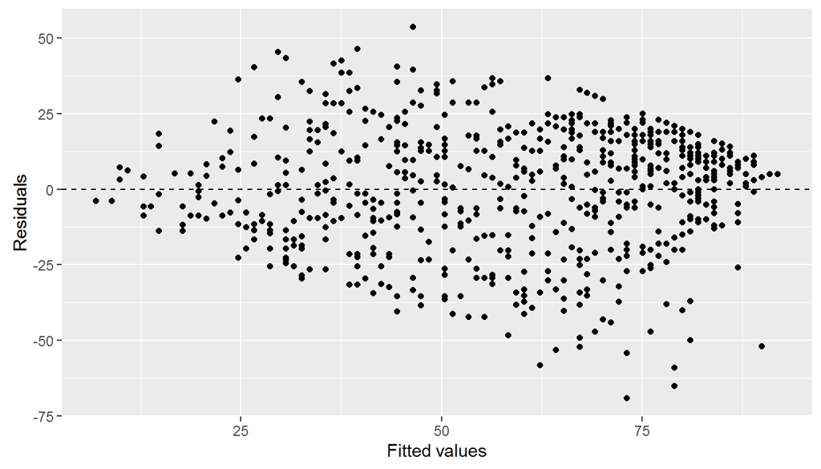

```r
ggplot(data = m0, aes(x = .fitted, y = .resid)) +
  geom_point() +
  geom_hline(yintercept = 0, linetype = "dashed") +
  xlab("Fitted values") +
  ylab("Residuals")
```

**Figure 4.2 Residual vs Fitted Values**

Figure 4.2 shows that the variability is lower when the fitted values are more extreme, and the variability is higher when the fitted values are in the middle two quartiles. This indicates that the critics and the audience tend to have similar rating on the best and the worst movies, but they have more disagreement on the average level movies. This phenomenon may be explained by two possible reasons: the first is that there are naturally fewer excellent and poor movies; the second reason is that the rating scores are trimmed at 0 and 100.

The histogram of the residuals is plotted in Figure 4.3. The distribution of the residuals is nearly normal, but slightly left skewed, which indicates that there are more underestimated points than overestimated points.

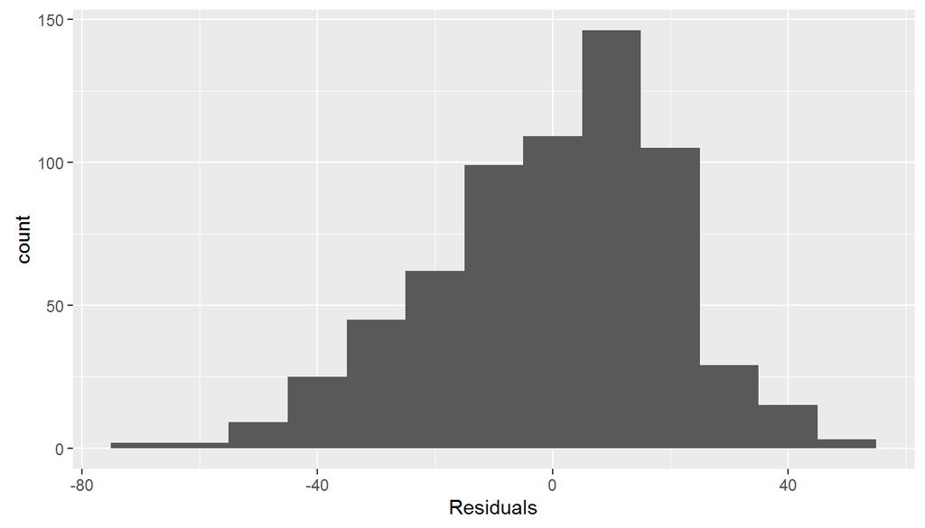

```r
ggplot(data = m0, aes(x = .resid)) +
  geom_histogram(binwidth = 10) +
  xlab("Residuals")
```

**Figure 4.3 Histogram of the Residuals**

The Q-Q plot in Figure 4.4 show a slightly curved pattern of points, indicating a slight left skew in the distribution. This agrees to the result from Figure 4.3.

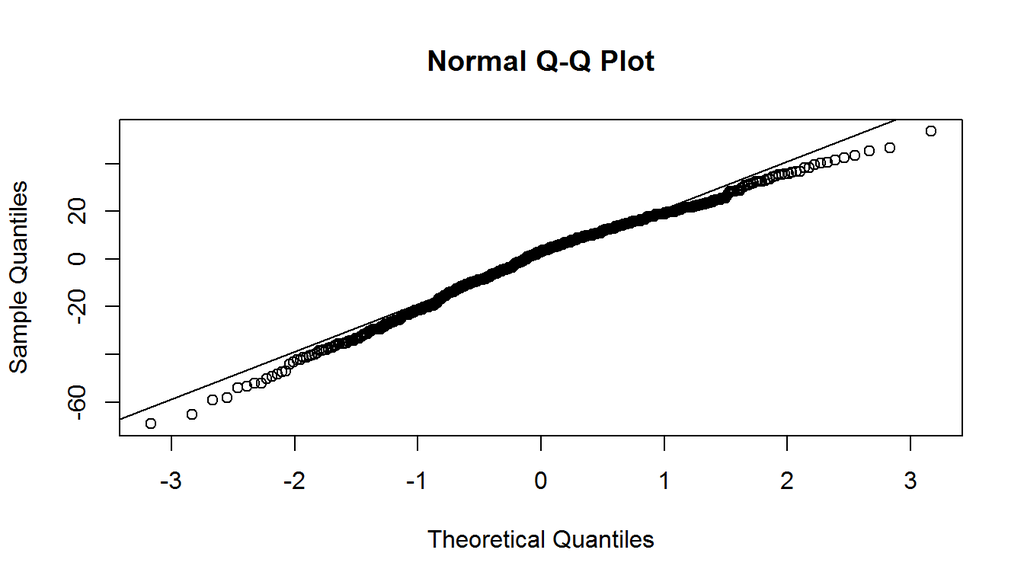

```r
qqnorm(m0$resid)
qqline(m0$resid)
```

**Figure 4.4 Normal Probability Plot of the Residuals**

The table and the figures above indicate that although the variability is not always constant, but it could be due to the mechanics of the rating. Beyond that, the conditions for linear regression have been met.

## **5. Multiple Predictors and Model Selection**

### 5.1 Multiple Predictors

In addition to the score of audience, the there are other factors that may affect the regression, such as the genre and type of the movie, etc. Three catagorical variables, the type of the movie `title_type`, the genre of the movie `genre` and the MPAA rating `mpaa_rating` of the movie were selected as the predictors to decribe the type of the movie.

### 5.2 Stepwise Forward Selection Using Adjusted R Square

A forward stepwise model selection method was used to decide if the predictor is significant to the regression. The adjusted R-squared was used as the criterion. The process of selection starts with the model described in Chapter 4 and add one predictor at a time until the parsimonious model is reached.

#### Step 0

Predictor: audience score

```r
m0 <- lm(critics_score ~ audience_score, data = movies)
summary(m0)$adj.r.squared
```

```
## [1] 0.4952284
```

#### Step 1

Predictor: audience score;

Additional predictors: title type, genre and MPAA rating.

```r
m1 <- lm(critics_score ~ title_type + audience_score, data = movies)
summary(m1)$adj.r.squared
```

```
## [1] 0.5080561
```

```r
m1 <- lm(critics_score ~ genre + audience_score, data = movies)
summary(m1)$adj.r.squared
```

```
## [1] 0.519975
```

```r
m1 <- lm(critics_score ~ mpaa_rating + audience_score, data = movies)
summary(m1)$adj.r.squared
```

```
## [1] 0.5112652
```

```
Result: genre leads to an increased adjusted R, add genre to the model.
```

#### Step 2

Predictor: audience score, genre;

Additional predictors: title type and MPAA rating.

```r
m1 <- lm(critics_score ~ genre + audience_score, data = movies)
summary(m1)$adj.r.squared
```

```
## [1] 0.519975
```

```r
m2 <- lm(critics_score ~ title_type + genre + audience_score, data = movies)
summary(m2)$adj.r.squared
```

```
## [1] 0.5263015
```

```r
m2 <- lm(critics_score ~ mpaa_rating + genre + audience_score, data = movies)
summary(m2)$adj.r.squared
```

```
## [1] 0.5293939
```

```
Result: MPAA rating leads to an increased adjusted R, add MPAA rating to the model.
```

#### Step 3

Predictor: audience score, genre, and MPAA rating;

Additional predictors: title type.

```r
m2 <- lm(critics_score ~ mpaa_rating + genre + audience_score, data = movies)
summary(m2)$adj.r.squared
```

```
## [1] 0.5293939
```

```r
m3 <- lm(critics_score ~ title_type + mpaa_rating + genre + audience_score, data = movies)
summary(m3)$adj.r.squared
```

```
## [1] 0.5337427
```

```
Result: title type leads to an increased adjusted R, add title type to the model.
```

All the three catagorical variables were found to contribute to a higher adjusted R-squared, and they should all be added to the model to help improve the regression.

### 5.3 Model Diagnostics

The simple regression model was checked in Chapter 4. For the adjusted model with multiple predictors, thess conditions could also be verified in similar ways.

#### Variability:

A plot of the residuals vs. fitted (predicted) values was made in Figure 5.1.

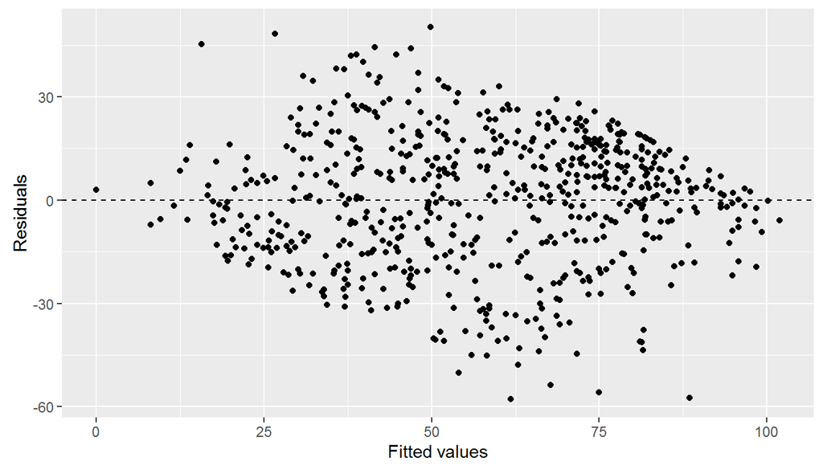

```r
ggplot(data = m3, aes(x = .fitted, y = .resid)) +
  geom_point() +
  geom_hline(yintercept = 0, linetype = "dashed") +
  xlab("Fitted values") +
  ylab("Residuals")
```

**Figure 5.1 Residuals vs. Fitted Values**

#### Nearly normal residuals:

A histogram of residuals is shown in Figure 5.2:

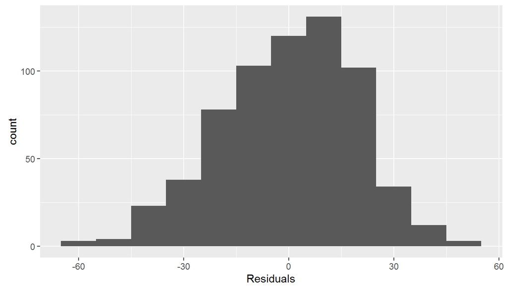

```r
ggplot(data = m3, aes(x = .resid)) +
  geom_histogram(binwidth = 10) +
  xlab("Residuals")
```

**Figure 5.2 Histogram of Residuals**

#### Independence of Residuals

A plot of residuals vs index is shown in Figure 5.3:

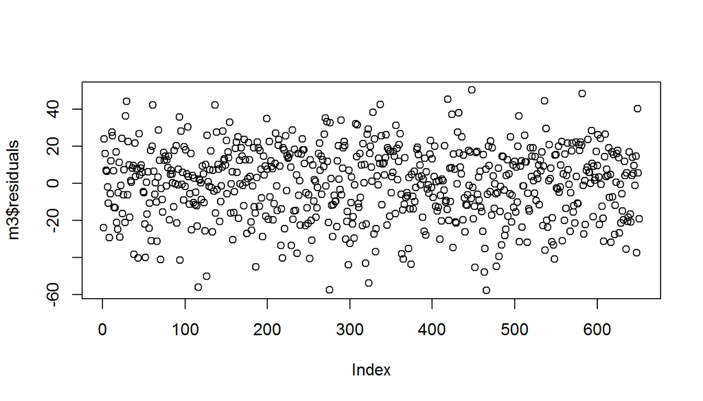

```r
plot(m3$residuals)
```

**Figure 5.3 Residuals vs Index**

In Figure 5.3, the residuals in the MLR appear to be independent of time series.

The results shown in the figures above are quite similar to those interpreted in Chapter 4. No other problems were found for this MLR.

### 5.4 Interpretation of model coefficients

The model is finally shown in the following equation:

$$\begin{aligned}
\widehat{critic\_score} &= \hat{\beta}_0 + \hat{\beta}_1 \times audience\_score + \hat{\beta}_2 \times genre + \hat{\beta}_3 \times mpaa_rating + \hat{\beta}_4 \times title\_type\\
\end{aligned}$$

The stats of the regression is shown in the following Table 5.1:

**Table 5.1 Coefficients**

```r
summary(m3)
```

```
##
## Call:
## lm(formula = critics_score ~ title_type + mpaa_rating + genre +
##     audience_score, data = movies)
##
## Residuals:
##     Min      1Q  Median      3Q     Max
## -57.777 -12.969   2.228  14.222  50.183
##
## Coefficients:
##                                 Estimate Std. Error t value Pr(>|t|)
## (Intercept)                     22.90632    9.37635   2.443  0.01484 *
## title_typeFeature Film         -20.22685    7.20352  -2.808  0.00514 **
## title_typeTV Movie             -18.24744   11.34844  -1.608  0.10835
## mpaa_ratingNC-17                13.81880   14.69261   0.941  0.34731
## mpaa_ratingPG                   -6.95814    5.32049  -1.308  0.19142
## mpaa_ratingPG-13               -12.35273    5.42294  -2.278  0.02307 *
## mpaa_ratingR                    -8.42188    5.26623  -1.599  0.11027
## mpaa_ratingUnrated              -0.38167    6.04831  -0.063  0.94970
## genreAnimation                  -4.79878    7.55588  -0.635  0.52559
## genreArt House & International  -0.75829    5.86247  -0.129  0.89712
## genreComedy                      1.16962    3.21040   0.364  0.71574
## genreDocumentary                -4.65614    7.73227  -0.602  0.54728
## genreDrama                      10.91683    2.76398   3.950 8.71e-05 ***
## genreHorror                      8.75851    4.82298   1.816  0.06984 .
## genreMusical & Performing Arts   4.11428    6.63133   0.620  0.53520
## genreMystery & Suspense         12.12364    3.57123   3.395  0.00073 ***
## genreOther                      11.46707    5.49300   2.088  0.03724 *
## genreScience Fiction & Fantasy  10.20977    6.90787   1.478  0.13991
## audience_score                   0.87535    0.04246  20.615  < 2e-16 ***
## ---
## Signif. codes:  0 '***' 0.001 '**' 0.01 '*' 0.05 '.' 0.1 ' ' 1
##
## Residual standard error: 19.39 on 632 degrees of freedom
## Multiple R-squared:  0.5467, Adjusted R-squared:  0.5337
## F-statistic: 42.34 on 18 and 632 DF,  p-value: < 2.2e-16
```

## **6. Prediction**

Using the model generated in Chapter 5, given a new movie with its audience score and its type, genre and MPAA rating, the score by the critics could be predicted. For example, the new movie “Suicide Squad” is an action & adventure feature film, with a MPAA rating of PG-13 and a average audience score of 74 (3.7 out of 5) on Rotten Tomatoes, the predicted score by critics is about 55.

```r
new_movie <- data.frame(genre = "Action & Adventure", mpaa_rating = "PG-13", title_type = "Feature Film", audience_score = 74)
predict(m3, new_movie)
```

```
##        1
## 55.10285
```

```r
predict(m3, new_movie, interval = "prediction", level = 0.95)
```

```
##        fit      lwr      upr
## 1 55.10285 16.55936 93.64634
```

The actual average critics score is 47 (4.7 out of 10) which falls into the predicted confidence interval.

## **7. Conclusion**

A Multiple Linear Regression was conducted utilizing a stepwise model selection method. The adjusted R-squared was used as the criterion of the selection. Three catagorical variables, genre, type and MPAA rating of the movie, in addition to the numerical variable, audience rating score, was found to be significant predictors of the critics score on the website “Rotten Tomatoes”. The model can be used for predicting the opinions of critics on movies, givena the audience score and some basic information about the movie.

## **8. Recommendations**

### Shortcomings of the MLR

Although the current model predicted the critic score successfully according to the information of the movie, the confidence interval is still rough compared to the full scare range. Other than the type information of the movies, other predictors such as whether there is an Oscar winning actor/actress or director may be significant to this regression. Further analysis is strongly recommended to take these information into consideration.

Moreover, the variability in the residuals of the regression showed some abnormal pattern, this may be due to the rating mechanics of the Rotten Tomatoes website. The critic score is a ten-point system while the audience score is a five-point system. This may cause a rounding bias. More advanced study in the rating system should be implemented to show the quality of the movie correctly.

## *Reference*

Movie title: Suicide Squad URL: ’https://www.rottentomatoes.com/m/suicide_squad_2016/